# Lab 3

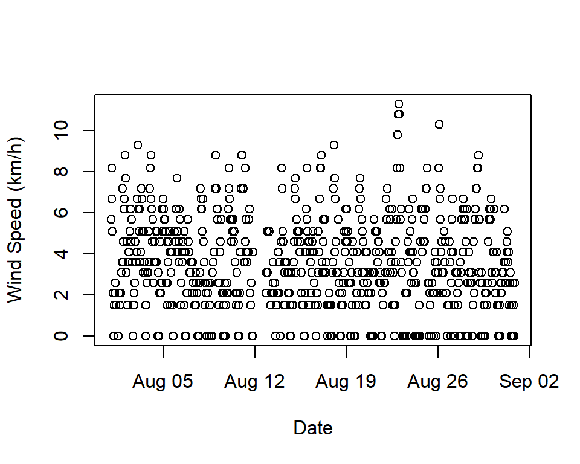

```r
plot(met_hot$date, met_hot$wind.sp, xlab="Date", ylab="Wind Speed (km/h)")
```

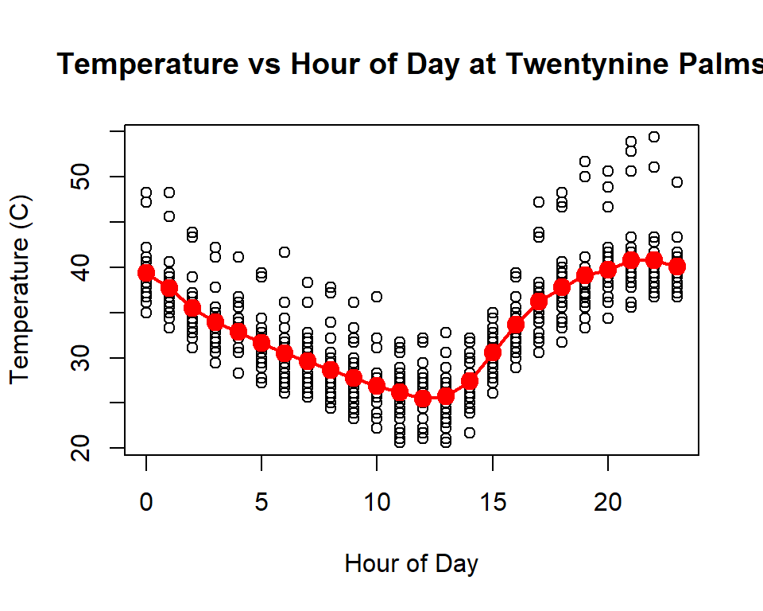

```r
hourly_means <- tapply(met_hot$temp, met_hot$hour, mean)

plot(met_hot$hour, met_hot$temp,
     xlab = "Hour of Day",
     ylab = "Temperature (C)",
     main = "Temperature vs Hour of Day at Twentynine Palms")

points(as.numeric(names(hourly_means)), hourly_means, col = "red", pch = 19, cex = 1.5)
lines(as.numeric(names(hourly_means)), hourly_means, col = "red", lwd = 2)
```

Answer: I am curious about the warmest place in my dataset (after filtering out the highest recorded temperature since that did not seem realistic). The warmest recorded temperature is now 54.4 C (130F) at a weather station near Los Angeles, so this heat seems realistic. I want to analyze the temperatures here to answer questions on whether these high temperatures are reasonable and how temperature varies at the station throughout the month and day.

A Google search of the hottest temperatures in this region has varying values depending on the station that recorded it. It seems that the hottest recorded temperatures in this region are closer to 110-120F, so 130F might not actually be realistic. However, this data recorded multiple values close to this range around the same days and time of day. Knowing whether these recorded temperatures are actually accurate might require contacting someone with expertise in this area, but if doing an analysis on the full dataset I would leave these values in because they seem realistic with the information I have.